# Supplemental Data and Code: Lineage and developmental patterns of DNA methylation in oysters

This notebook includes procedures for analyzing data desribed in  
the Master's thesis "DNA methylation variation in gametes and larvae of the Pacific oyster, *Crassostrea gigas*" by Claire Olson.

In theory, anyone should be able to reproduce our work in IPython, if they have the following software installed. * BSMAP * bedtools * R * rpy2 (interface to R from Python)

The analysis was originally done on the Mac OSX operating system.

The intent is to clone the github repository locally and run so accompaning scripts, etc. are available. Please note Data files that you will download and will produce are large (>20Gb).

The notebook is divided into 5 sections

- Downloading data
- Read aligning: BSMAP
- Global differences: methylkit
- Differentially methylated loci
- Genomic location of DMLs: bedtools

Please post any comments and questions in issues.

Before getting started, set the location o BSMAP on your computer and hit shift-enter

```python
bsmaploc="/Users/Shared/Apps/bsmap-2.74/"
```

# Downloading Data

```python
#to confirm you current directory run the command and you should see a wd directory
!ls
```

```
BiGo_dev_manu.html     README.md              wd
BiGo_dev_manu.ipynb    img
BiGo_dev_manu_V2.ipynb scripts
```

```python
cd wd
```

```
/Users/Steven/Desktop/olson-dev-master/wd
```

```python
#This command downloads a archived file including six BS-seq libraries (4.3 Gb)

#!wget http://eagle.fish.washington.edu/trilobite/Crassostrea_gigas_HTSdata/BiGo_lar_fastq_mcf.tgz
!curl -O http://eagle.fish.washington.edu/trilobite/Crassostrea_gigas_HTSdata/BiGo_lar_fastq_mcf.tgz
```

```
  % Total    % Received % Xferd  Average Speed   Time    Time     Time  Current
                                 Dload  Upload   Total   Spent    Left  Speed
100 4221M  100 4221M    0     0  61.3M      0  0:01:08  0:01:08 --:--:-- 82.1M
```

```python
#uncompress files
!tar -zxvf BiGo_lar_fastq_mcf.tgz
```

```
x mcf_M1_R1.fastq
x mcf_M1_R2.fastq
x mcf_M3_R1.fastq
x mcf_M3_R2.fastq
x mcf_T1D3_R1.fastq
x mcf_T1D3_R2.fastq
x mcf_T1D5_R1.fastq
x mcf_T1D5_R2.fastq
x mcf_T3D3_R1.fastq
x mcf_T3D3_R2.fastq
x mcf_T3D5_R1.fastq
x mcf_T3D5_R2.fastq
```

```python
#Downloading the oyster genome
#!wget http://eagle.fish.washington.edu/trilobite/Crassostrea_gigas_ensembl_tracks/Crassostrea_gigas.GCA_000297895.1.22.dna_sm.genome.fa
!curl -O http://eagle.fish.washington.edu/trilobite/Crassostrea_gigas_ensembl_tracks/Crassostrea_gigas.GCA_000297895.1.22.dna_sm.genome.fa
```

```
  % Total    % Received % Xferd  Average Speed   Time    Time     Time  Current
                                 Dload  Upload   Total   Spent    Left  Speed
100  541M  100  541M    0     0  71.5M      0  0:00:07  0:00:07 --:--:-- 73.1M
```

# Running BSMAP

```python
#bsmap will need to be downloaded if not already installed from https://code.google.com/p/bsmap/
#another option in running bsmap on iPlant (iplantcollaborative.org)
```

```python
for i in ("M1","T1D3","T1D5", "M3", "T3D3", "T3D5"):
    !{bsmaploc}bsmap \
-a mcf_{i}_R1.fastq \
-b mcf_{i}_R2.fastq \
-d Crassostrea_gigas.GCA_000297895.1.22.dna_sm.genome.fa \
-o bsmap_out_{i}.sam \
-p 4
```

[output not shown]

[output cut: 942 more lines]

```
Thread #1: 	6800000 read pairs finished. 560 secs passed
Thread #0: 	6850000 read pairs finished. 564 secs passed
Thread #2: 	6900000 read pairs finished. 566 secs passed
Thread #3: 	6950000 read pairs finished. 572 secs passed
Thread #1: 	7000000 read pairs finished. 575 secs passed
Thread #0: 	7050000 read pairs finished. 579 secs passed
Thread #3: 	7125800 read pairs finished. 579 secs passed
Thread #2: 	7100000 read pairs finished. 580 secs passed
Total number of aligned reads:
pairs:       4092568 (57%)
single a:    1250715 (18%)
single b:    1133306 (16%)
Done.
Finished at Tue Dec  2 15:00:40 2014
Total time consumed:  580 secs
```

# *methratio*

methratio is a python script that accompanies BSMAP that determines methylation level on CpG loci

```python
for i in ("M1","T1D3","T1D5", "M3", "T3D3", "T3D5"):
    !python {bsmaploc}methratio.py \
-d Crassostrea_gigas.GCA_000297895.1.22.dna_sm.genome.fa \
-u -z -g \
-o methratio_out_{i}.txt \
-s {bsmaploc}samtools \
bsmap_out_{i}.sam \
```

```
@ Wed Dec  3 04:00:08 2014: reading reference Crassostrea_gigas.GCA_000297895.1.22.dna_sm.genome.fa ...
@ Wed Dec  3 04:00:42 2014: reading bsmap_out_M1.sam ...
[samopen] SAM header is present: 7658 sequences.
	@ Wed Dec  3 04:05:20 2014: read 10000000 lines
@ Wed Dec  3 04:05:44 2014: combining CpG methylation from both strands ...
@ Wed Dec  3 04:06:07 2014: writing methratio_out_M1.txt ...
@ Wed Dec  3 04:15:07 2014: done.
total 8716467 valid mappings, 48671764 covered cytosines, average coverage: 1.78 fold.
@ Wed Dec  3 04:15:08 2014: reading reference Crassostrea_gigas.GCA_000297895.1.22.dna_sm.genome.fa ...
@ Wed Dec  3 04:15:42 2014: reading bsmap_out_T1D3.sam ...
[samopen] SAM header is present: 7658 sequences.
@ Wed Dec  3 04:18:10 2014: combining CpG methylation from both strands ...
@ Wed Dec  3 04:18:34 2014: writing methratio_out_T1D3.txt ...
@ Wed Dec  3 04:24:04 2014: done.
total 5759215 valid mappings, 26507310 covered cytosines, average coverage: 1.32 fold.
@ Wed Dec  3 04:24:05 2014: reading reference Crassostrea_gigas.GCA_000297895.1.22.dna_sm.genome.fa ...
@ Wed Dec  3 04:24:39 2014: reading bsmap_out_T1D5.sam ...
[samopen] SAM header is present: 7658 sequences.
@ Wed Dec  3 04:28:39 2014: combining CpG methylation from both strands ...
@ Wed Dec  3 04:29:03 2014: writing methratio_out_T1D5.txt ...
@ Wed Dec  3 04:37:34 2014: done.
total 6974208 valid mappings, 45446465 covered cytosines, average coverage: 1.54 fold.
@ Wed Dec  3 04:37:35 2014: reading reference Crassostrea_gigas.GCA_000297895.1.22.dna_sm.genome.fa ...
@ Wed Dec  3 04:38:09 2014: reading bsmap_out_M3.sam ...
[samopen] SAM header is present: 7658 sequences.
	@ Wed Dec  3 04:42:53 2014: read 10000000 lines
@ Wed Dec  3 04:43:39 2014: combining CpG methylation from both strands ...
@ Wed Dec  3 04:44:03 2014: writing methratio_out_M3.txt ...
@ Wed Dec  3 04:54:10 2014: done.
total 9773223 valid mappings, 53389886 covered cytosines, average coverage: 1.78 fold.
@ Wed Dec  3 04:54:11 2014: reading reference Crassostrea_gigas.GCA_000297895.1.22.dna_sm.genome.fa ...
@ Wed Dec  3 04:54:47 2014: reading bsmap_out_T3D3.sam ...
[samopen] SAM header is present: 7658 sequences.
	@ Wed Dec  3 04:59:30 2014: read 10000000 lines
@ Wed Dec  3 04:59:48 2014: combining CpG methylation from both strands ...
@ Wed Dec  3 05:00:12 2014: writing methratio_out_T3D3.txt ...
@ Wed Dec  3 05:09:49 2014: done.
total 8847902 valid mappings, 52255860 covered cytosines, average coverage: 1.65 fold.
@ Wed Dec  3 05:09:51 2014: reading reference Crassostrea_gigas.GCA_000297895.1.22.dna_sm.genome.fa ...
@ Wed Dec  3 05:10:24 2014: reading bsmap_out_T3D5.sam ...
[samopen] SAM header is present: 7658 sequences.
	@ Wed Dec  3 05:15:09 2014: read 10000000 lines
@ Wed Dec  3 05:15:25 2014: combining CpG methylation from both strands ...
@ Wed Dec  3 05:15:49 2014: writing methratio_out_T3D5.txt ...
@ Wed Dec  3 05:25:16 2014: done.
total 8808414 valid mappings, 51732152 covered cytosines, average coverage: 1.69 fold.
```

# Global Differences: methylkit

**Converting methratio files for methylkit**

```python
#first methratio files are converted to filter for CG context, 3x coverage (mr3x.awk), and reformatting (mr_gg.awk.sh).
#due to issue passing variable to awk, simple scripts were used (included in repository)
for i in ("M1","T1D3","T1D5", "M3", "T3D3", "T3D5"):
    !echo {i}
    !grep "[A-Z][A-Z]CG[A-Z]" <methratio_out_{i}.txt> methratio_out_{i}CG.txt
    !awk -f ../scripts/mr3x.awk methratio_out_{i}CG.txt > mr3x.{i}.txt
    !awk -f ../scripts/mr_gg.awk.sh mr3x.{i}.txt > mkfmt_{i}.txt
```

```
M1
T1D3
T1D5
M3
T3D3
T3D5
```

**Running R > methylkit**

```python
%pylab inline
```

```python
%load_ext rpy2.ipython
```

```python
%%R
# dependencies
install.packages( c("data.table","devtools"))
source("http://bioconductor.org/biocLite.R")
biocLite(c("GenomicRanges","IRanges"))

# install the development version from github
library(devtools)
install_github("al2na/methylKit",build_vignettes=FALSE)
```

[output not shown]

```python
%R library(methylKit)
```

```
array(['methylKit', 'devtools', 'BiocInstaller', 'tools', 'stats',
       'graphics', 'grDevices', 'utils', 'datasets', 'methods', 'base'],
      dtype='|S13')
```

```python
%%R file.list <- list
('mkfmt_M1.txt',
 'mkfmt_T1D3.txt',
 'mkfmt_T1D5.txt',
 'mkfmt_M3.txt',
 'mkfmt_T3D3.txt',
 'mkfmt_T3D5.txt'
)
```

```python
%%R
myobj=read(file.list,sample.id=list("1_sperm","1_72hpf","1_120hpf","3_sperm","3_72hpf","3_120hpf"),assembly="v9",treatment=c(0,0,0,1,1,1))
```

```
The "ward" method has been renamed to "ward.D"; note new "ward.D2"
```

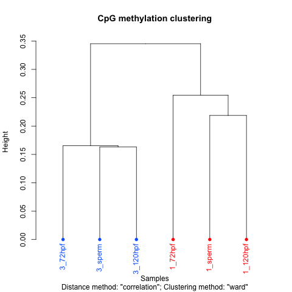

```python
%%R
meth<-unite(myobj)
head(meth)
nrow(meth)
#getCorrelation(meth,plot=T)
hc<- clusterSamples(meth, dist="correlation", method="ward", plot=T)
#PCA<-PCASamples(meth)
```

# Differentially methylated loci

Determining differentially methylated loci using methylkit

```python
%%R
#lineage-specific DMLs
#note that file.list was defined in prior section
DMLobj=read(file.list,sample.id=list("M1","T1D3","T1D5","M3","T3D3","T3D5"),assembly="v9",treatment=c(1,1,1,0,0,0), context="CpG")
lin<-unite(DMLobj)
lin.pooled <- pool(lin, sample.ids <- c("lin_1", "lin_3"))
lin_DML.fisher <- calculateDiffMeth(lin.pooled)
select(lin_DML.fisher, 1)
lin_DML_p <- getData(lin_DML.fisher)
lin_DML_filt <- lin_DML_p[lin_DML_p$pvalue < 0.01 & lin_DML_p$meth.diff > 25,]
write.csv(lin_DML_filt,file="lin_DML_filt")
```

```python
!wc -l lin_DML_filt
```

```
     190 lin_DML_filt
```

### Next will determine differentially methylated loci during development. This is done by doing three pairwise comparisons

```python
%%R file.list <- list
('mkfmt_M1.txt',
 'mkfmt_T1D3.txt',
 'mkfmt_M3.txt',
 'mkfmt_T3D3.txt'
)
```

```python
%%R
#Developmentally different DMLs (Males v Day3)
DMLobj=read(file.list,sample.id=list("M1","T1D3","M3","T3D3"), assembly="v9",treatment=c(1,0,1,0), context="CpG")
DevelMvD3<-unite(DMLobj)
DevelMvD3.pooled <- pool(DevelMvD3, sample.ids <- c("Males", "Day3"))
DevelMvD3_DML.fisher <- calculateDiffMeth(DevelMvD3.pooled)
select(DevelMvD3_DML.fisher, 1)
DevelMvD3_DML_p <- getData(DevelMvD3_DML.fisher)
DevelMvD3_DML_filt <- DevelMvD3_DML_p[DevelMvD3_DML_p$pvalue < 0.01 & DevelMvD3_DML_p$meth.diff > 25,]
write.csv(DevelMvD3_DML_filt,file="DevelMvD3_DML_filt")
```

```python
!wc -l DevelMvD3_DML_filt
```

```
      30 DevelMvD3_DML_filt
```

```python
%%R file.list <- list
('mkfmt_M1.txt',
 'mkfmt_T1D5.txt',
 'mkfmt_M3.txt',
 'mkfmt_T3D5.txt'
)
```

```python
%%R
#Developmentally different DMLs (Males v Day5)
DMLobj=read(file.list,sample.id=list("M1","T1D5","M3","T3D5"), assembly="v9",treatment=c(1,0,1,0), context="CpG")
DevelMvD5<-unite(DMLobj)
DevelMvD5.pooled <- pool(DevelMvD5, sample.ids <- c("Males", "Day5"))
DevelMvD5_DML.fisher <- calculateDiffMeth(DevelMvD5.pooled)
select(DevelMvD5_DML.fisher, 1)
DevelMvD5_DML_p <- getData(DevelMvD5_DML.fisher)
DevelMvD5_DML_filt <- DevelMvD5_DML_p[DevelMvD5_DML_p$pvalue < 0.01 & DevelMvD5_DML_p$meth.diff > 25,]
write.csv(DevelMvD5_DML_filt,file="DevelMvD5_DML_filt")
```

```python
!wc -l DevelMvD5_DML_filt
```

```
      86 DevelMvD5_DML_filt
```

```python
%%R file.list <- list
('mkfmt_T1D3.txt',
 'mkfmt_T1D5.txt',
 'mkfmt_T3D3.txt',
 'mkfmt_T3D5.txt'
)
```

```python
%%R
#Developmentally different DMLs (Day3 v Day5)
DMLobj=read(file.list,sample.id=list("T1D3","T1D5","T3D3","T3D5"), assembly="v9",treatment=c(1,0,1,0), context="CpG")
DevelD3vD5<-unite(DMLobj)
DevelD3vD5.pooled <- pool(DevelD3vD5, sample.ids <- c("Day3", "Day5"))
DevelD3vD5_DML.fisher <- calculateDiffMeth(DevelD3vD5.pooled)
select(DevelD3vD5_DML.fisher, 1)
DevelD3vD5_DML_p <- getData(DevelD3vD5_DML.fisher)
DevelD3vD5_DML_filt <- DevelD3vD5_DML_p[DevelD3vD5_DML_p$pvalue < 0.01 & DevelD3vD5_DML_p$meth.diff > 25,]
write.csv(DevelD3vD5_DML_filt,file="DevelD3vD5_DML_filt")
```

```python
!wc -l DevelD3vD5_DML_filt
```

```
      47 DevelD3vD5_DML_filt
```

```python
#removing column titles
!tail -n +2 DevelMvD5_DML_filt > DevelMvD5_DML
!tail -n +2 DevelD3vD5_DML_filt > DevelD3vD5_DML
```

```python
#Concatenate all developmetnally different DMLs to one file
!cat DevelMvD3_DML_filt DevelMvD5_DML DevelD3vD5_DML > Devel_DML_filt
```

```python
!wc -l Devel_DML_filt
```

```
     161 Devel_DML_filt
```

### Creating DML BED files

```python
!tail -n +2 lin_DML_filt | awk -F, '{print $2, $3, $4, "DML_lin" }' | tr -d '"' | tr ' ' "\t"  > lineage_dml.bed
```

```python
!head lineage_dml.bed
```

```
C23232	379	379	DML_lin
C26004	260	260	DML_lin
C26812	1897	1897	DML_lin
C27566	2051	2051	DML_lin
C27928	1300	1300	DML_lin
C27928	1323	1323	DML_lin
C30526	1477	1477	DML_lin
C33236	10478	10478	DML_lin
C33236	10483	10483	DML_lin
C34176	2127	2127	DML_lin
```

```python
!wc -l lineage_dml.bed
```

```
     189 lineage_dml.bed
```

```python
!tail -n +2 Devel_DML_filt | awk -F, '{print $2, $3, $4, "DML_dev" }' | tr -d '"' | tr ' ' "\t"  > dev_dml.bed
```

```python
!head dev_dml.bed
```

```
C24224	2053	2053	DML_dev
C30124	6380	6380	DML_dev
scaffold1024	1265774	1265774	DML_dev
scaffold1103	28814	28814	DML_dev
scaffold1103	30261	30261	DML_dev
scaffold1188	81327	81327	DML_dev
scaffold1297	43485	43485	DML_dev
scaffold1337	180233	180233	DML_dev
scaffold1423	296279	296279	DML_dev
scaffold1896	38848	38848	DML_dev
```

```python
!wc -l dev_dml.bed
```

```
     160 dev_dml.bed
```

# Genomic location of DMLs

```python
#In order to find location of DMLs oyster genome tracks will be downloaded
#and intersectbed (bedtools suite) run
#Note track with all CG's is large (~977mb)
```

```python
cd genome_tracks
```

```
/Users/Steven/Desktop/olson-dev-master/wd/genome_tracks
```

```python
for i in ("exon","intron","TE","gene","1k5p_gene_promoter","CG"):
    !curl -O --test http://eagle.fish.washington.edu/trilobite/Crassostrea_gigas_v9_tracks/Cgigas_v9_{i}.gff
```

[output not shown]

```python
cd ..
```

```
/Users/Steven/Desktop/olson-dev-master/wd
```

```python
for i in ("exon","intron","TE","1k5p_gene_promoter"):
    !intersectbed \
    -u \
    -a lineage_dml.bed \
    -b ./genome_tracks/Cgigas_v9_{i}.gff \
    > {i}_intersect_DML_lin_u.txt
    !wc -l {i}_intersect_DML_lin_u.txt > lin{i}
```

```python
!cat linintron linexon lin1k5p_gene_promoter linTE > dmltable
```

```python
!head dmltable
```

```
      42 intron_intersect_DML_lin_u.txt
      25 exon_intersect_DML_lin_u.txt
       8 1k5p_gene_promoter_intersect_DML_lin_u.txt
      27 TE_intersect_DML_lin_u.txt
```

```python
!awk 'FNR==NR{sum+=$1;next}; {print $0,sum}' dmltable{,} > lin_total
```

```python
!head lin_total
```

```
      42 intron_intersect_DML_lin_u.txt 102
      25 exon_intersect_DML_lin_u.txt 102
       8 1k5p_gene_promoter_intersect_DML_lin_u.txt 102
      27 TE_intersect_DML_lin_u.txt 102
```

```python
!awk '{print $2, $1, $3, (($1/$3)*100)}' lin_total > lin_final
```

```python
!head lin_final
```

```
intron_intersect_DML_lin_u.txt 42 102 41.1765
exon_intersect_DML_lin_u.txt 25 102 24.5098
1k5p_gene_promoter_intersect_DML_lin_u.txt 8 102 7.84314
TE_intersect_DML_lin_u.txt 27 102 26.4706
```

```python
for i in ("exon","intron","TE","1k5p_gene_promoter"):
    !intersectbed \
    -u \
    -a dev_dml.bed \
    -b ./genome_tracks/Cgigas_v9_{i}.gff \
    > {i}_intersect_DML_dev_u.txt
    !wc -l {i}_intersect_DML_dev_u.txt > dev{i}
```

```python
!cat devintron devexon dev1k5p_gene_promoter devTE  > devtable
```

```python
!head devtable
```

```
      60 intron_intersect_DML_dev_u.txt
      13 exon_intersect_DML_dev_u.txt
       6 1k5p_gene_promoter_intersect_DML_dev_u.txt
      20 TE_intersect_DML_dev_u.txt
```

```python
!awk 'FNR==NR{sum+=$1;next}; {print $0,sum}' devtable{,} > dev_total
```

```python
!head dev_total
```

```
      60 intron_intersect_DML_dev_u.txt 99
      13 exon_intersect_DML_dev_u.txt 99
       6 1k5p_gene_promoter_intersect_DML_dev_u.txt 99
      20 TE_intersect_DML_dev_u.txt 99
```

```python
!awk '{print $2, $1, $3, (($1/$3)*100)}' dev_total > dev_final
```

```python
!head dev_final
```

```
intron_intersect_DML_dev_u.txt 60 99 60.6061
exon_intersect_DML_dev_u.txt 13 99 13.1313
1k5p_gene_promoter_intersect_DML_dev_u.txt 6 99 6.06061
TE_intersect_DML_dev_u.txt 20 99 20.202
```

```python
for i in ("exon","intron","TE","gene","1k5p_gene_promoter"):
    !intersectbed \
    -u \
    -a ./genome_tracks/Cgigas_v9_CG.gff \
    -b ./genome_tracks/Cgigas_v9_{i}.gff \
    > {i}_intersect_CG_u.txt
    !wc -l {i}_intersect_CG_u.txt > CG{i}
```

```python
!cat CGintron CGexon CG1k5p_gene_promoter CGTE > CGtable
```

```python
!head CGtable
```

```
 2815997 intron_intersect_CG_u.txt
 1129658 exon_intersect_CG_u.txt
  593081 1k5p_gene_promoter_intersect_CG_u.txt
  589509 TE_intersect_CG_u.txt
```

```python
!awk 'FNR==NR{sum+=$1;next}; {print $0,sum}' CGtable{,} > CG_total
```

```python
!head CG_total
```

```
 2815997 intron_intersect_CG_u.txt 5128245
 1129658 exon_intersect_CG_u.txt 5128245
  593081 1k5p_gene_promoter_intersect_CG_u.txt 5128245
  589509 TE_intersect_CG_u.txt 5128245
```

```python
!awk '{print $2, $1, $3, (($1/$3)*100)}' CG_total > CG_final
```

```python
!head CG_final
```

```
intron_intersect_CG_u.txt 2815997 5128245 54.9115
exon_intersect_CG_u.txt 1129658 5128245 22.0282
1k5p_gene_promoter_intersect_CG_u.txt 593081 5128245 11.565
TE_intersect_CG_u.txt 589509 5128245 11.4953
```

```python
!paste -d" " lin_final dev_final CG_final > StackedBars
```

```python
!awk '{print $4, $8, $12}' StackedBars | tr ' ' "\t" > StackedBars_DMLs
```

# Stacked Bar Plot of DMLs versus all CGs

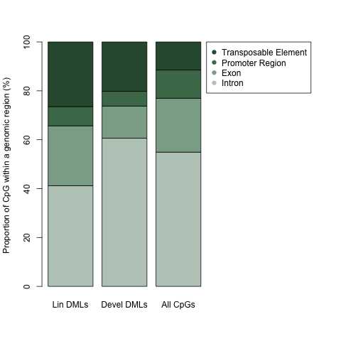

```python
%%R
DMLs<-as.matrix(read.table('StackedBars_DMLs', header=F))
colnames(DMLs)<-c("Lin DMLs","Devel DMLs", "All CpGs")
par(mar=c(5.1, 4.1, 4.1, 8.1), xpd=T)
par(xpd=T, mar=par()$mar+c(0,0,0,5))
barplot(as.matrix(DMLs), col=c("#BCCCC1", "#8DAB96", "#4A7958", "#2F583B"), ylab="Proportion of CpG within a genomic region (%)")
legend("topright",inset=c(-0.63,-0), legend=c("Transposable Element", "Promoter Region", "Exon", "Intron"), pch=c(19,19,19), col=c("#2F583B","#4A7958","#8DAB96","#BCCCC1"))
```